# r4ds Chapter 3 - Data Visualisation

Gabriel J. Odom, PhD, ThD

gabriel.odom@med.miami.edu

January 15, 2018

# 1 Introduction

This lecture is drawn nearly exclusively from Hadley Wickham and Garrett Grolemund’s text **R for Data Science**, [Chapter 3](http://r4ds.had.co.nz/data-visualisation.html#introduction-1). This book is available on [Amazon](https://smile.amazon.com/Data-Science-Transform-Visualize-Model/dp/1491910399/ref=sr_1_3?ie=UTF8&qid=1515618027&sr=8-3&keywords=r+for+data+science), and it’s currently (as of 10 January 2018) half off.

## 1.1 Motivating Example: SNAP Usage by ZIP Code

First things first, why should you care about what we are talking about today? Why should you come back for the next three classes? Because, we are going to learn how to make this:

[figure not shown]

This graph shows a map of South Florida, upon which we have plotted the boundaries of all the Miami-Dade and Broward county ZIP Codes. Within these ZIP Code boundaries, we’ve plotted the proportion of households receiving food stamp / SNAP benefits (according to the 2016 Census).

## 1.2 A Toy Example

Before we can start our analysis, we first load the requisite packages.

```r
# install.packages("tidyverse")
library(tidyverse)
```

We will begin by answering a simple question: is fuel efficiency associated with engine size? If so, how? *(We will assume that our data is already nice and clean. If your data is ugly, stick around for the next two classes!)* Let’s load and look at our Miles per Gallon data set (which is in the `ggplot2::` package). While I don’t need to save the data set (because it is stored in the `ggplot2::` package), I’m going to take the opportunity to show you the assignment operator in R: `<-`.

```r
mpg <- ggplot2::mpg
mpg
```

```
## # A tibble: 234 x 11
##    manufacturer model displ  year   cyl trans drv     cty   hwy fl    class
##    <chr>        <chr> <dbl> <int> <int> <chr> <chr> <int> <int> <chr> <chr>
##  1 audi         a4      1.8  1999     4 auto~ f        18    29 p     comp~
##  2 audi         a4      1.8  1999     4 manu~ f        21    29 p     comp~
##  3 audi         a4      2    2008     4 manu~ f        20    31 p     comp~
##  4 audi         a4      2    2008     4 auto~ f        21    30 p     comp~
##  5 audi         a4      2.8  1999     6 auto~ f        16    26 p     comp~
##  6 audi         a4      2.8  1999     6 manu~ f        18    26 p     comp~
##  7 audi         a4      3.1  2008     6 auto~ f        18    27 p     comp~
##  8 audi         a4 q~   1.8  1999     4 manu~ 4        18    26 p     comp~
##  9 audi         a4 q~   1.8  1999     4 auto~ 4        16    25 p     comp~
## 10 audi         a4 q~   2    2008     4 manu~ 4        20    28 p     comp~
## # ... with 224 more rows
```

If we want to find out more about this data set, we can ask `R` for help. In order to ask for help about any *documented* object or package, we can use the `?` command.

```r
?ggplot2::mpg
```

This opens the *package documentation* associated with the `mpg` data set from the `ggplot2::` package. It tells us where the data is from and information about the variables recorded in the data set.

## 1.3 Data Structure

Now, if you’re not familiar with the `tidyverse` functions and data structures, that “tibble” thing may be unfamiliar to you. Basically, it’s like `R`’s version of an Excel spreadsheet. Let’s find out what `R` considers the `mpg` object. We will use the `str()` function (it stands for the “structure”) to find out what `R` says about this `mpg` object.

```r
str(mpg)
```

```
## Classes 'tbl_df', 'tbl' and 'data.frame':    234 obs. of  11 variables:
##  $ manufacturer: chr  "audi" "audi" "audi" "audi" ...
##  $ model       : chr  "a4" "a4" "a4" "a4" ...
##  $ displ       : num  1.8 1.8 2 2 2.8 2.8 3.1 1.8 1.8 2 ...
##  $ year        : int  1999 1999 2008 2008 1999 1999 2008 1999 1999 2008 ...
##  $ cyl         : int  4 4 4 4 6 6 6 4 4 4 ...
##  $ trans       : chr  "auto(l5)" "manual(m5)" "manual(m6)" "auto(av)" ...
##  $ drv         : chr  "f" "f" "f" "f" ...
##  $ cty         : int  18 21 20 21 16 18 18 18 16 20 ...
##  $ hwy         : int  29 29 31 30 26 26 27 26 25 28 ...
##  $ fl          : chr  "p" "p" "p" "p" ...
##  $ class       : chr  "compact" "compact" "compact" "compact" ...
```

The `mpg` object has three classes: `tbl_df`, `tbl`, and `data.frame`. The `str()` function is one of your most sleuthing powerful tools to troubleshoot your `R` code. Notice the `$` symbol preceeding the column name. That is our method for selecting an individual column: `data_frame$column_name`.

## 1.4 The “Tidy” Data Style

Another thing to notice in our data frame is that each column is a variable and each row is a unique data point. This data format is known as “tidy” data, and [this paper](https://www.jstatsoft.org/article/view/v059i10) in the Journal of Statistical Software discusses why it is the most proper format to store rectangular data. Like we said earlier, a `data.frame` is similar to an Excel spreadsheet. We can also see the number of rows (234 `obs.`) and columns (11 `variables`) this data frame has, and the names of these columns.

## 1.5 Exercises:

1. Install and load the `MASS` package.
2. Find the structure and number of observations and variables in the `Boston` data set from this package. Which features are continuous? Discrete?
3. Use the `?` command to find out what the `medv` measurement represents.

# 2 Our First `ggplot` Graph

Now that we know a little about our data, we know that the variable `displ` stands for engine displacement in litres. This will be our measurement for the size of the engine. Further, we know that `cty` and `hwy` are the variables measuring city and highway MPG, respectively. With this information in hand, let’s plot the relationship between engine size and highway MPG.

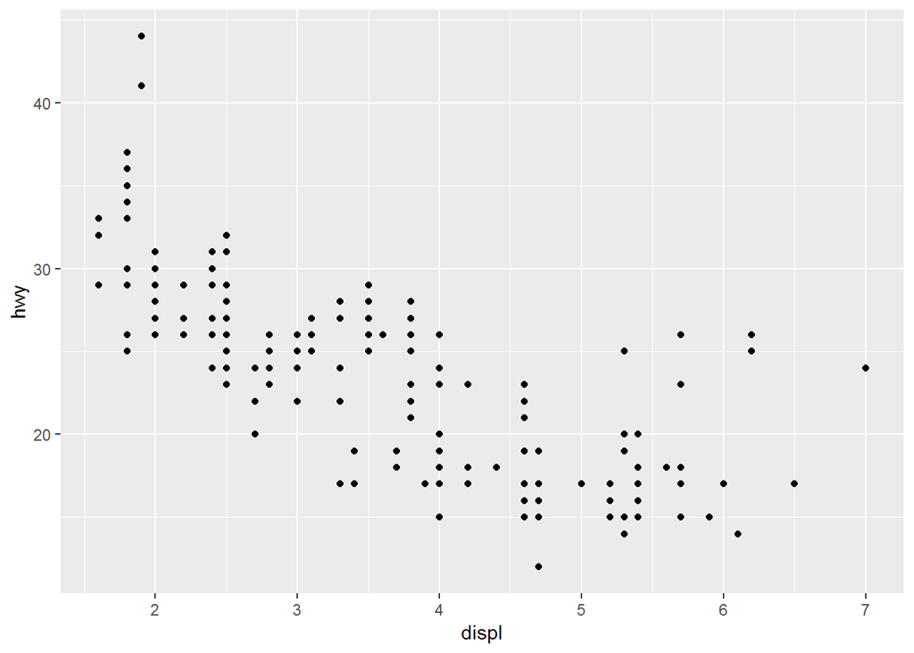

```r
ggplot(data = mpg,
       mapping = aes(x = displ, y = hwy)) +
  geom_point()
```

## 2.1 Three Components of a `ggplot`

There are three main components of the code to build this graph: the `data` argument, the `mapping` argument, and the `geom_*()` function. These components are organized in a logical manner and with a corresponding set of rules: these rules are called a *grammar*. That’s what the `gg` part stands for – the *grammar* of *graphics*.

### 2.1.1 The `data =` Argument

The `ggplot()` function takes tidy data frames only. Using the `str()` function, we already confirmed that:

- `mpg` is a dataframe, and
- the `mpg` data frame is “tidy” (observations are rows, measurements are columns).

If you ever have trouble with `ggplot()`, make sure your data frame is tidy! If your data frame is not tidy, see this [R-Bloggers post](https://www.r-bloggers.com/how-to-reshape-data-in-r-tidyr-vs-reshape2/) on using the `reshape2::` or `tidyr::` packages to format your data in a tidy manner.

### 2.1.2 `mapping` to an Aesthetic with `aes()`

We will talk about aesthetics in detail in the next section, but for now understand that `mapping` is how you tell `ggplot()` where your data goes. We are telling `ggplot()` to put engine size on the x-axis (`x = displ`) and highway fuel economy on the y-axis (`y = hwy`), all with the `aes()` function. As we will see in the next section, there are many more aesthetics we can map our measurements to.

### 2.1.3 The `geom_*()` Function

We told the `ggplot()` function where to find the data with the `data =` argument. We told the function which pieces we care about and how to related them with the `aes()` function to the `mapping =` argument. Now we need to tell `ggplot()` *how* to plot `x` and `y`. This is where the the `geom_*()` functions come into play: we wanted a scatterplot, so we picked `geom_point()`. “Geom” is short for “geometric object”, and there are quite a few geometric shapes we can bend our data into.

### 2.1.4 The “Secret” `+` Component

If you are more familiar with `R`, but not familiar with the `tidyverse`, then the idea of “adding” one function to another seems absurd. In the `tidyverse` world, however, think of this `+` sign as a way to “add” a layer to a graph. As you’ll see soon, we can “add” more and more to a single graph with this `+` operator.

Look back to the figure. You might notice that there is a group of five points that stick out: these cars have large engines but higher MPG than other vehicles with large engines. We could ask a few questions to try to explain this disparity:

- Are these vehicles hybrids?
- Do these vehicles use diesel?
- Are these vehicles newer?

Each question is a hypothesis, and we will attempt to “test” these hypotheses visually in the next section.

## 2.2 Exercises:

Using the `Boston` data set:

1. Create a scatterplot with median home value on the horizontal axis and average number of rooms on the vertical axis.
2. Create a scatterplot with age of the home on the horizontal axis and median home value on the vertical axis.
3. Think about a few features you believe could influence median home value. Create some hyptheses to visually “test”. We’ll keep these hypotheses for the next few sections.

# 3 Plotting Three (or More) Variables using Aesthetics

The `ggplot()` function allows us to add a third variable to a two-dimensional scatterplot by mapping this variable to an *aesthetic*. In our previous graph, the x-axis and y-axis were *aesthetics*, passed on to the `ggplot()` function through the `aes()` function. There are quite a few aesthetics to choose from to modify our scatterplot:

- `colour`: What color to make our points? Good for continuous or discrete features.
- `size`: How big should the points be? Better for continuous features.
- `alpha`: How opaque / transparent should the points be? Values range from $[0,1]$, with $1$ being completely opaque. Better for continuous features.
- `shape`: What shape should the points have? Better for discrete features. Options are shown below

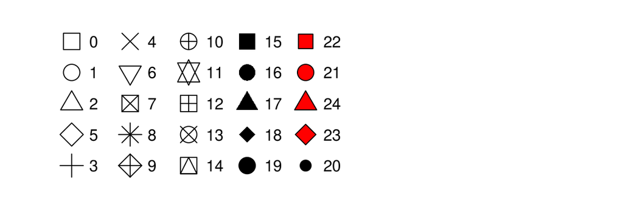

- `fill`: For the shapes filled with red, what color should you put instead? Better for discrete features, but is limited when plotting points. The `fill` aesthetic truly shines with geoms other than `point`, but more on that later.

For most of these aesthetics, the behavior of the graph will change depending on if you map a discrete or continuous feature to it. For example, if you map a continuous feature, such as a `numeric` or `interger` feature, to the `colour` aesthetic, the points will be given a color gradient (by default, from dark blue to light blue). However, if you map a discrete value, such as a `character` or `factor` feature to the `colour` aesthetic, the points will be distinctly different in color.

## 3.1 Claim 1: Outlier Cars are Hybrids

Let’s take a look at all the possible unique values for vehicle type. Remember that we can check the help documentation for the data set if we’re unsure of which column measures the type. Remember that we use the `$` symbol to access a specific column of a data frame.

```r
unique(mpg$class)
```

```
## [1] "compact"    "midsize"    "suv"        "2seater"    "minivan"
## [6] "pickup"     "subcompact"
```

```r
str(mpg$class)
```

```
##  chr [1:234] "compact" "compact" "compact" "compact" "compact" ...
```

The `str()` function informs us that this feature is a `character` feature, and therefore discrete. Therefore, we can add it to the graph with the `colour` or `shape` aesthetics.

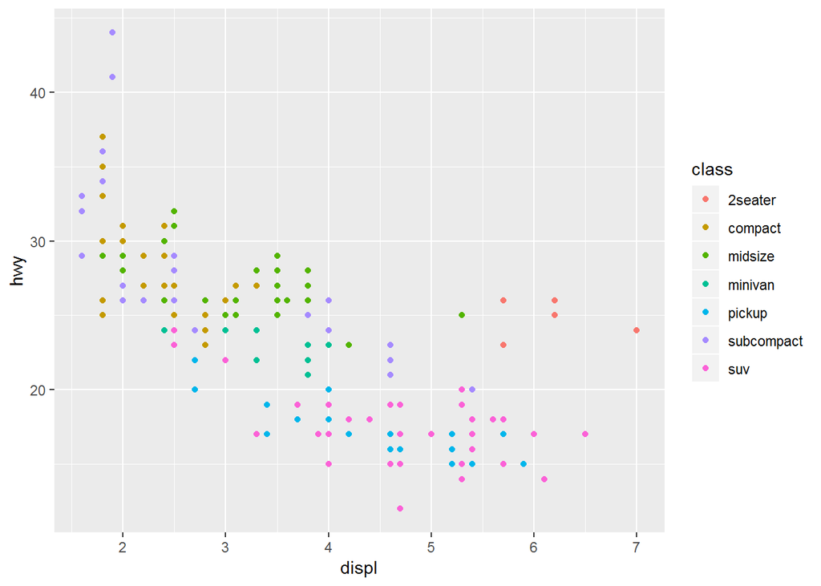

```r
ggplot(data = mpg,
       mapping = aes(x = displ, y = hwy, colour = class)) +
  geom_point()
```

It appears that our hypothesis was incorrect. These vehicles are not small, hybrid cars at all, but sportscars or midsize cars.

## 3.2 Claim 2: Outlier Cars take Diesel

Let’s take a look at all the possible unique values for vehicle fuel.

```r
unique(mpg$fl)
```

```
## [1] "p" "r" "e" "d" "c"
```

This feature is a `character` feature. Because the fuel type is discrete, we can add it to the graph with the `colour` or `shape` aesthetics.

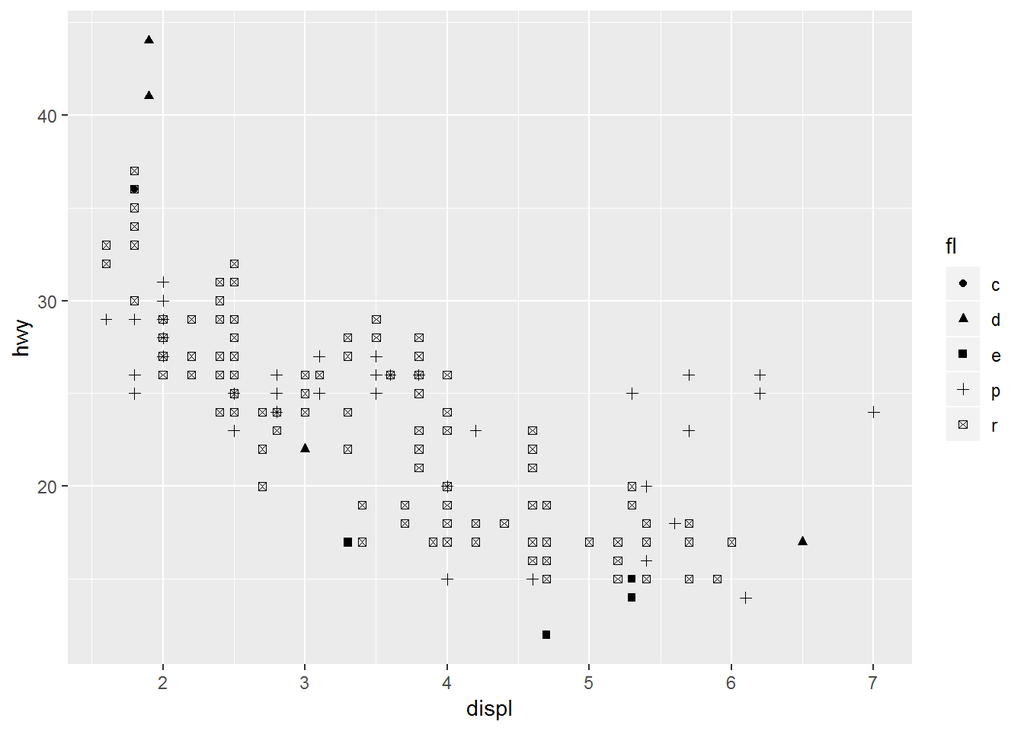

```r
ggplot(data = mpg,
       mapping = aes(x = displ, y = hwy, shape = fl)) +
  geom_point()
```

Our hypothesis is incorrect. It appears that all five of our outlier vehicles take premium fuel, not diesel. This graph, when paired with the previous graph on car class, gives us a better understanding of factors that could influence the relationship between engine size and fuel economy.

## 3.3 Claim 3: Outlier Cars are Newer

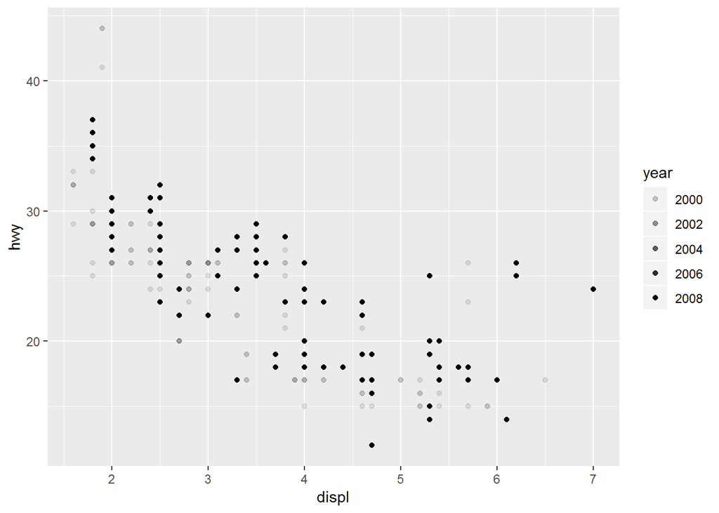

```r
ggplot(data = mpg,
       mapping = aes(x = displ, y = hwy, alpha = year)) +
  geom_point()
```

The manufacture year doesn’t help explain the five outlier points very well.

## 3.4 Updated Claim: Outlier Cars are Sportscars

We can add more than 3 features to a plot. Let’s create an engine size by MPG plot with fuel type *and* car class added.

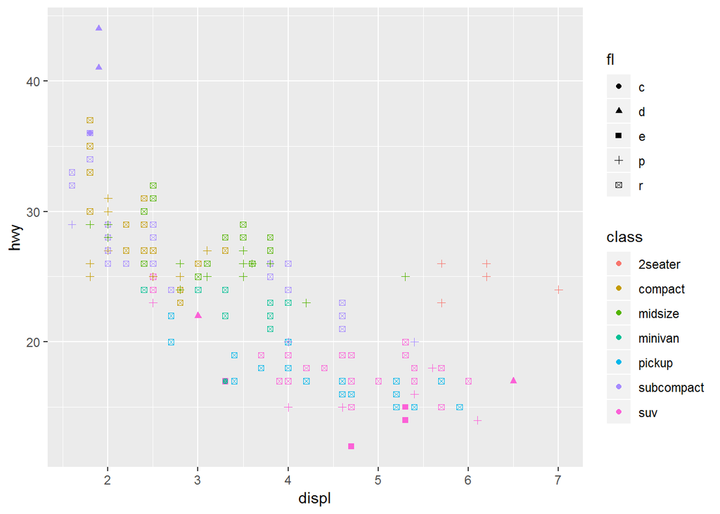

```r
ggplot(data = mpg,
       mapping = aes(x = displ, y = hwy, colour = class, shape = fl)) +
  geom_point()
```

If you’re thinking to yourself, “I wish there was a way to clean this graph up, to only show the premium fuel and two-seater cars”, then come back for the “Data Manipulation with `dplyr`” session! Not to fear, we will also discuss a way to break graphs into mutually-exclusive pieces, called *facets*, next.

## 3.5 Excercises

Using the `Boston` data set: try to test some of the hypotheses you made about home value at the end of the last section. Remember that some aesthetics are better for discrete features, while others are better for continuous features.

# 4 Group by a Facet

Facets allow us to split our graphs over a categorical variable. Let’s repeat the previous graph, but split over fuel type.

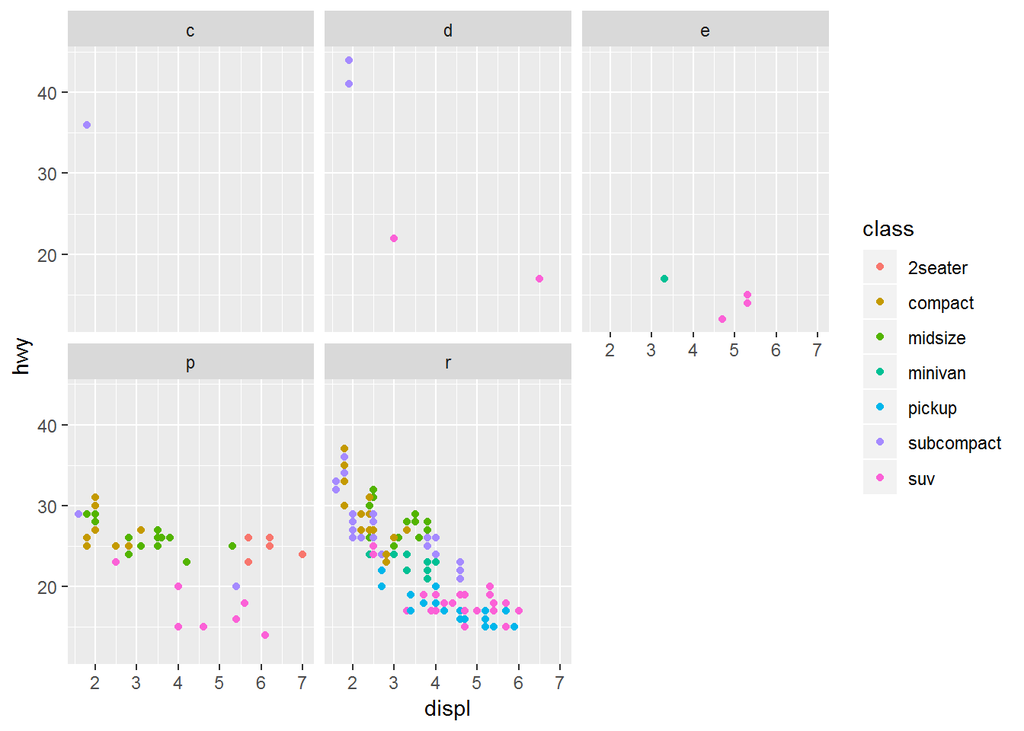

```r
ggplot(data = mpg,
       mapping = aes(x = displ, y = hwy, colour = class)) +
  geom_point() +
  facet_wrap(~ fl, nrow = 2)
```

We see a much stronger negative linear relationship between engine size and fuel economy for vehicles using regular petrol instead of premium.

Now what if we wanted facet on two features? Let’s inspect how the number of cylinders in the engine, as well as the manufacturing year, affect the relationship between engine size and city fuel economy.

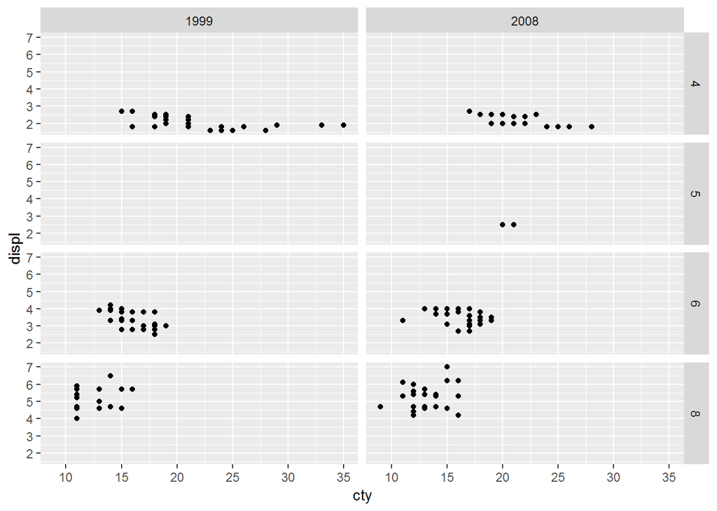

```r
ggplot(data = mpg,
       mapping = aes(x = displ, y = cty)) +
  geom_point() +
  facet_grid(cyl ~ year) +
  coord_flip()
```

Notice that flipping the coordinates (via the `coord_flip()` command) allows use to see any differences in city fuel economy better. From this graph, the manufacture year doesn’t seem to have much of an effect, other than that very small cars with four-cylinder engines lose a little fuel economy.

## 4.1 Exercise:

Using the `Boston` data set: test the hypotheses from last section, but facet on the Charles River indicator variable.

# 5 Shaping Up your Data with Geoms

As we mentioned in the Introduction, there are many Geoms we can use to plot our data. Let’s compare two geoms, `geom_point()` and `geom_smooth()`. We can use the `grid.arrange()` function from the `gridExtra::` package to put two plots side-by-side.

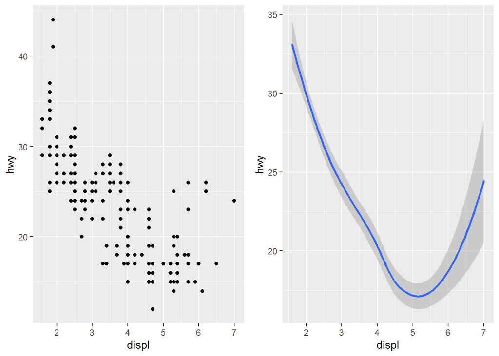

```r
# install.packages("gridExtra")
library(gridExtra)
plot1 <- ggplot(data = mpg,
       mapping = aes(x = displ, y = hwy)) +
  geom_point()
plot2 <- ggplot(data = mpg,
       mapping = aes(x = displ, y = hwy)) +
  geom_smooth()
grid.arrange(plot1, plot2, ncol=2)
```

We can also layer geoms on top of each other.

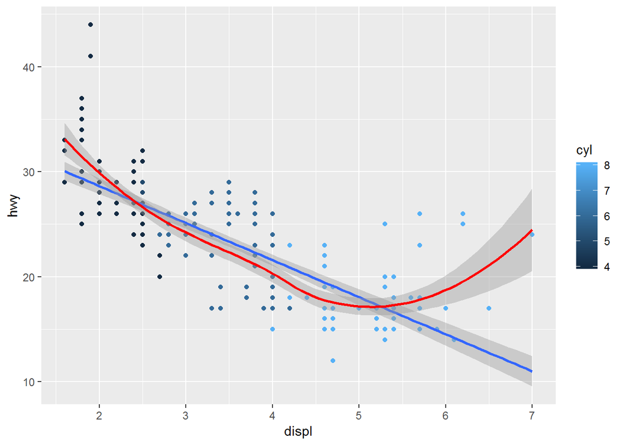

```r
ggplot(data = mpg,
       mapping = aes(x = displ, y = hwy)) +
  geom_point(aes(colour = cyl)) +
  geom_smooth(method = "lm") +
  geom_smooth(colour = "red")
```

Notice that we are comparing the relationship between engine size and highway fuel economy while accounting for the number of cylinders effect, and overlaying the output from a linear model (blue) and a LOESS smoother (red).

# 6 Our First `ggmap` Plot

Now that we understand how the grammar of graphics works, then we know that we could potentially use any data for our `x` and `y` aesthetics, including longitude and latitude from a map. Unfortunately, our skills in *data transformation* are still very weak (this is my shameless plug for the February and March classes), so we’ll only make a simple map for now.

[figure not shown]

```r
# install.packages("ggmap")
# library(ggmap)
# miami_ggmap <- get_map(location = "miami", zoom = 9)
ggmap(miami_ggmap)
```

We can also download a map from a single location. Because `ggmap` uses the same grammar as `ggplot`, we can add on a point to mark the Soffer Clinical Research Building.

EDIT: The fascists at Google now require an API key, so we are skipping this section.

```r
CRB_ggmap <- get_map(location = c(lon = -80.212960, lat = 25.787107),
                           zoom = 15)
```

```
## Error: Google now requires an API key.
##        See ?register_google for details.
```

```r
ggmap(CRB_ggmap) +
  ggtitle("Don Soffer Clinical Research Building") +
  labs(x = "Longitude", y = "Latitude") +
  geom_point(aes(x = -80.212960, y = 25.787107),
             colour = "red", size = 3)
```

```
## Error in ggmap(CRB_ggmap): object 'CRB_ggmap' not found
```

## 6.1 Exercise:

Build a map of your neighborhood, using the latitude and longitude your home.